# Reproducible_Research_Assingment_1

Paul M.

2022-10-31

## Loading and preprocessing the data

```r
data <- read.csv('~/activity.csv')
```

##What is mean total number of steps taken per day? #For this part of the assignment, you can ignore the missing values in the dataset.

```r
daysteps <- tapply(data$steps, data$date, sum, na.rm=TRUE)
summary(daysteps)
```

```
##    Min. 1st Qu.  Median    Mean 3rd Qu.    Max.
##       0    6778   10395    9354   12811   21194
```

#### 1. Make a histogram of the total number of steps taken each day

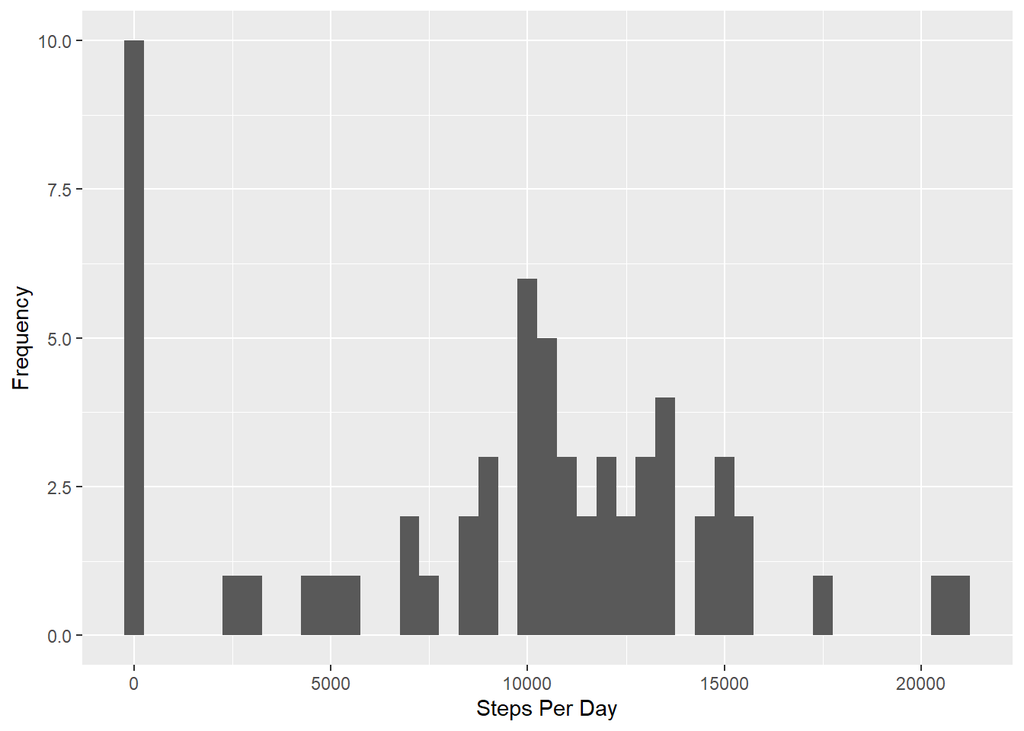

```r
qplot(daysteps, xlab='Steps Per Day', ylab='Frequency', binwidth=500)
```

#### 2. Calculate and report the mean and median total number of steps taken per day

```r
daystepsMean <- mean(daysteps)
daystepsMedian <- median(daysteps)
```

- Mean: 9354.2295082
- Median: 10395

## What is the average daily activity pattern?

```r
averagep<- aggregate(x=list(meanSteps=data$steps), by=list(interval=data$interval), FUN=mean, na.rm=TRUE)
summary(averagep)
```

```
##     interval        meanSteps
##  Min.   :   0.0   Min.   :  0.000
##  1st Qu.: 588.8   1st Qu.:  2.486
##  Median :1177.5   Median : 34.113
##  Mean   :1177.5   Mean   : 37.383
##  3rd Qu.:1766.2   3rd Qu.: 52.835
##  Max.   :2355.0   Max.   :206.170
```

#### 1. Make a time series plot

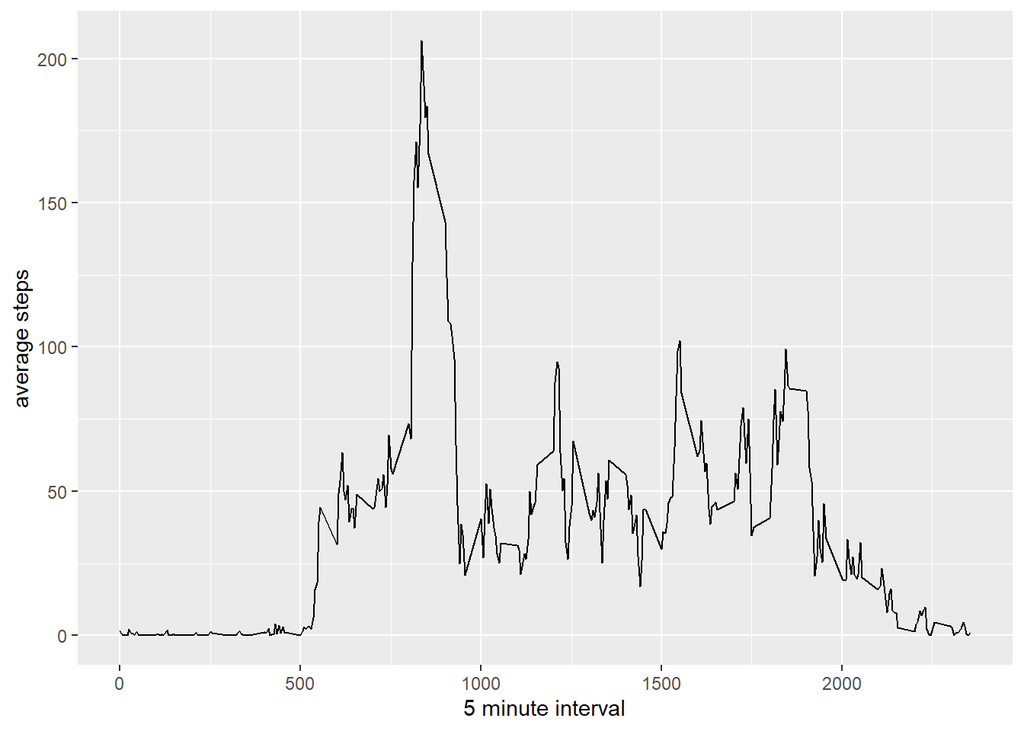

```r
ggplot(data=averagep, aes(x=interval, y=meanSteps)) +
    geom_line() +
    xlab("5 minute interval") +
    ylab("average steps")
```

#### 2. Which 5-minute interval, on average across all the days in the dataset, contains the maximum number of steps?

```r
maxsteps <- which.max(averagep$meanSteps)
timemax <-  gsub("([0-9]{1,2})([0-9]{2})", "\\1:\\2", averagep[maxsteps,'interval'])
```

- Most Steps at: 8:35

## Imputing missing values

#### 1. Calculate and report the total number of missing values in the dataset

```r
null <- length(which(is.na(data$steps)))
```

- Number of missing values: 2304

##### 2. Devise a strategy for filling in all of the missing values in the dataset.

##### 3. Create a new dataset that is equal to the original dataset but with the missing data filled in.

```r
DataImputed <- data
DataImputed$steps <- impute(data$steps, fun=mean)
```

##### 4. Make a histogram of the total number of steps taken each day

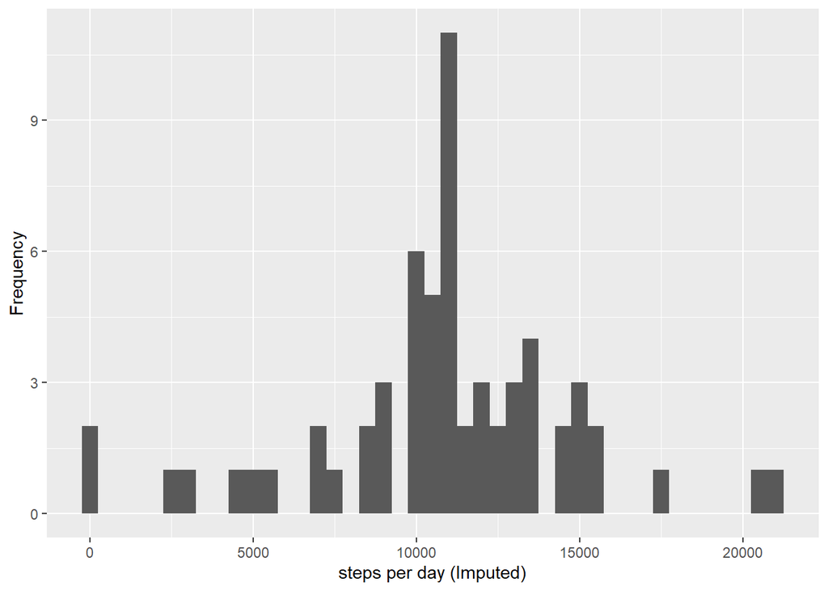

```r
stepsImputed <- tapply(DataImputed$steps, DataImputed$date, sum)
qplot(stepsImputed, xlab='steps per day (Imputed)', ylab='Frequency', binwidth=500)
```

##### Calculate and report the mean and median total number of steps taken per day.

```r
MeanImputed <- mean(stepsImputed)
MedianImputed <- median(stepsImputed)
```

- Mean (Imputed): 1.0766189^{4}
- Median (Imputed): 1.0766189^{4}

## Are there differences in activity patterns between weekdays and weekends?

##### 1. Create a new factor variable in the dataset with two levels – “weekday” and “weekend” indicating whether a given date is a weekday or weekend day.

```r
DataImputed$dateType <-  ifelse(as.POSIXlt(DataImputed$date)$wday %in% c(0,6), 'weekend', 'weekday')
```

##### 2. Make a panel plot containing a time series plot

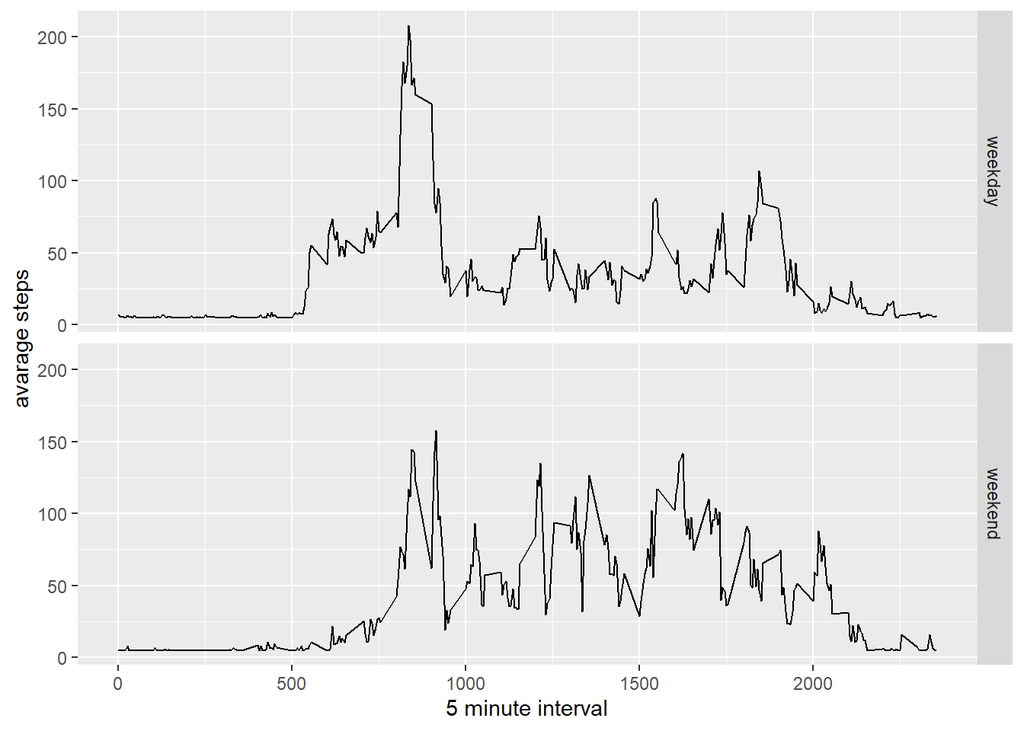

```r
avgDataImputed <- aggregate(steps ~ interval + dateType, data=DataImputed, mean)
ggplot(avgDataImputed, aes(interval, steps)) +
    geom_line() +
    facet_grid(dateType ~ .) +
    xlab("5 minute interval") +
    ylab("avarage steps")
```